# Hoja de Trabajo No.5

## Numpy, Pandas, Vectorización

### Presentado por: Margerys Salgado

#### Librerias

```python
import pandas as pd
import numpy as np
import matplotlib.pyplot as plt
```

### Numpy

##### Ejercicio 1: Crear un conjunto de datos lineal

Crear un conjunto de datos simple que consta de una sola característica y una etiqueta de la siguiente manera:

Asigne una secuencia de números enteros del 6 al 20 (incluyendo 20) a un arreglo de NumPy llamado caracteristica. Asigne 15 valores a un arreglo de NumPy llamado etiqueta de manera que:

```
etiqueta = (3) (caracteristica) + 4
```

Por ejemplo, el primer valor de etiqueta debería ser:

```
etiqueta = (3) (6) + 4 = 22
```

```python
caracteristica = np.array([6, 7, 8, 9, 10, 11, 12, 13, 14, 15, 16, 17, 18, 19, 20])
etiqueta = 3 * caracteristica + 4
print(etiqueta)
```

```
[22 25 28 31 34 37 40 43 46 49 52 55 58 61 64]
```

```python
type(etiqueta)
etiqueta.shape
```

```
(15,)
```

##### Ejercicio 2: Agregar ruido al conjunto de datos

Inserte un ruido aleatorio en cada elemento de la matriz etiqueta que ya creó. Para ser más precisos, modifique cada valor asignado a etiqueta agregando un valor "floating-point" aleatorio diferente entre -2 y +2. No utilice broadcasting. En su lugar, cree un arreglo de ruido que tenga la misma dimensión que etiqueta.

```python
import numpy as np
RA = np.random.uniform(-2, 2, size=(1, 15))

print(RA)
```

```
[[-0.68020555 -0.77485151 -1.9522889   0.01584376  1.80862472  0.96710332
  -0.50796217  0.94270172  0.38460866 -0.64226078  1.70504665 -0.75461094
   1.8118973   1.85205363 -0.25323732]]
```

```python
etiqueta2 = etiqueta + RA
print(etiqueta2)
```

```
[[21.31979445 24.22514849 26.0477111  31.01584376 35.80862472 37.96710332
  39.49203783 43.94270172 46.38460866 48.35773922 53.70504665 54.24538906
  59.8118973  62.85205363 63.74676268]]
```

### Pandas

##### Ejericio 3: Crear un DataFrame

Cree un pandas DataFrame de 10x3 (10 filas x 3 columnas) en el que las columnas se denominen "Data Warehouse", "Python in Data Science", y "Estadistica Aplicada". Llene cada una de las 30 celdas del DataFrame con un número entero aleatorio entre 0 y 100, incluyendo 100.

Despliege lo siguiente:

1. Todo el DataFrame
2. Las primeras 5 filas del DataFrame
3. Las ultimas 5 filas del DataFrame
4. El valor en la celda de la fila # 1 de la columna "Data Warehouse"
5. El valor en la celda de la fila # 3 de la columna "Estadistica Aplicada"
6. Cree una cuarta columna llamada "Promedio", que se rellena con el promedio fila por fila de las otras 3 columnas ("Data Warehouse", "Python in Data Science", y "Estadistica Aplicada"). Debe de usar la funcion de Numpy para calcular el promedio.

Para completar esta parte, es útil entender los conceptos básicos de NumPy cubiertos en clase y en la seccion anterior.

###### 1. Todo el DataFrame

```python
import pandas as pd
np.random.randint(100, size=(10, 3))
```

```
array([[16, 33, 75],
       [41, 35, 25],
       [41, 15, 81],
       [74, 47,  0],
       [52, 94, 77],
       [65, 91, 13],
       [22, 96, 10],
       [69, 79, 76],
       [19, 69, 67],
       [94, 74, 80]])
```

```python
a = np.random.randint(100, size=(10, 3))
df = pd.DataFrame(data=a, columns=['Data Warehouse', 'Python in Data Science', 'Estadistica Aplicada'])
print(df)
```

```
   Data Warehouse  Python in Data Science  Estadistica Aplicada
0               5                      67                    20
1               7                      17                    82
2              50                      20                    71
3              18                      24                    39
4              81                      66                    77
5              68                      80                    68
6              29                      95                    22
7              43                      99                    75
8              95                      87                    88
9              34                       2                    61
```

###### 2. Las primeras 5 filas del DataFrame

```python
df.head()
```

|  | Data Warehouse | Python in Data Science | Estadistica Aplicada |
| --- | --- | --- | --- |
| 0 | 5 | 67 | 20 |
| 1 | 7 | 17 | 82 |
| 2 | 50 | 20 | 71 |
| 3 | 18 | 24 | 39 |
| 4 | 81 | 66 | 77 |

###### 3. Las ultimas 5 filas del DataFrame

```python
df.tail(5)
```

|  | Data Warehouse | Python in Data Science | Estadistica Aplicada |
| --- | --- | --- | --- |
| 5 | 68 | 80 | 68 |
| 6 | 29 | 95 | 22 |
| 7 | 43 | 99 | 75 |
| 8 | 95 | 87 | 88 |
| 9 | 34 | 2 | 61 |

###### 4. El valor en la celda de la fila No. 1 de la columna "Data Warehouse"

```python
df["Data Warehouse"]
```

[output not shown]

###### 5. El valor en la celda de la fila No. 3 de la columna "Estadistica Aplicada"

```python
df.loc[2, 'Estadistica Aplicada']
```

```
71
```

###### 6. Cree una cuarta columna llamada "Promedio"

Que se rellena con el promedio fila por fila de las otras 3 columnas. Debe de usar la funcion de Numpy para calcular el promedio.

```python
df.insert(3, 'Prom', df.mean(axis=1))
df
```

|  | Data Warehouse | Python in Data Science | Estadistica Aplicada | Prom |
| --- | --- | --- | --- | --- |
| 0 | 5 | 67 | 20 | 30.666667 |
| 1 | 7 | 17 | 82 | 35.333333 |
| 2 | 50 | 20 | 71 | 47.000000 |
| 3 | 18 | 24 | 39 | 27.000000 |
| 4 | 81 | 66 | 77 | 74.666667 |
| 5 | 68 | 80 | 68 | 72.000000 |
| 6 | 29 | 95 | 22 | 48.666667 |
| 7 | 43 | 99 | 75 | 72.333333 |
| 8 | 95 | 87 | 88 | 90.000000 |
| 9 | 34 | 2 | 61 | 32.333333 |

### Vectorización

A continuacion, se le presenta un problema el cual debera resolver de dos formas distintas. La primera es utilizando un for loop, la segunda usando vectorización. Luego debe de comparar el resultado de ambas implementaciones, tanto el valor resultante de la operacion, como el tiempo que toma la ejecucion de cada una. Problema: Dada una secuencia de precios historicos para una acción, y suponiendo que solo se le permite realizar una compra y una venta, ¿cuál es la ganancia máxima que se puede obtener? Por ejemplo, dados los precios = (20, 18, 14, 17, 20, 21, 13), el beneficio máximo sería 7, de comprar a 14 y vender a 21. Notar que el arreglo es una secuencia, por lo tanto no es factible solo utilizar los valores menores y mayores, ya que el valor mayor debe de estar obligatoriamente en una posicion futura al menor, por eso el mejor precio de compra es 14 y no 13. Para este ejemplo utilice el siguiente codigo para generar el dataset (secuencia de precios historicos), asegurese de tambien incluir el "random seed" para obtener reproducibilidad.

###### Data

```python
# Seed para reproducibilidad
np.random.seed(42)
# Creamos un arreglo que en su mayoria contiene Nans con algunos "puntos de inflexion" (local min/max).
precios = np.full(100, fill_value=np.nan)
precios[[0, 25, 60, -1]] = [80., 30., 75., 50.]

# De manera lineal interpolamos los valores faltantes y agregamos ruido.
x = np.arange(len(precios))
es_valido = ~np.isnan(precios)
precios = np.interp(x=x, xp=x[es_valido], fp=precios[es_valido])
precios += np.random.randn(len(precios)) * 2
precios
```

```
array([80.99342831, 77.7234714 , 77.29537708, 77.04605971, 71.53169325,
       69.53172609, 71.15842563, 67.53486946, 63.06105123, 63.08512009,
       59.07316461, 57.06854049, 56.48392454, 50.17343951, 48.55016433,
       48.87542494, 45.97433776, 46.62849467, 42.18395185, 39.1753926 ,
       42.93129754, 37.5484474 , 36.13505641, 31.15050363, 30.91123455,
       30.22184518, 28.98372713, 33.32282461, 32.65586548, 34.55946964,
       35.2251582 , 41.41884208, 38.97300555, 38.17029243, 43.2165184 ,
       40.41545556, 44.56058433, 41.50923118, 44.05791362, 48.39372247,
       50.76264745, 50.91416513, 51.62584629, 52.54064975, 51.47152745,
       54.2745973 , 56.07872246, 60.39995874, 60.25866515, 57.33106255,
       62.79102508, 62.65840687, 63.36044171, 67.22335258, 69.34771333,
       70.43398881, 68.17870781, 70.52443239, 73.09109829, 75.66537597,
       74.04165152, 73.98765641, 71.50527877, 70.68450983, 74.06094908,
       74.50735185, 71.00982591, 72.51988631, 70.59506692, 67.94052972,
       69.3125348 , 71.02479108, 67.23604023, 69.79595398, 60.78615082,
       67.02842039, 64.91768388, 63.5045494 , 63.64506001, 58.84537499,
       61.7401434 , 62.25268668, 63.85322399, 59.21986982, 57.99839741,
       57.97084489, 60.16413757, 58.34980991, 55.99176164, 57.43679128,
       55.96338587, 57.06549511, 53.0830733 , 53.19082955, 52.4209119 ,
       49.63707267, 52.51531748, 51.80416183, 50.65125255, 49.53082573])
```

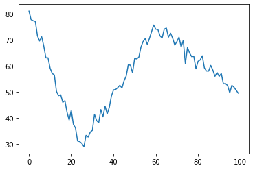

```python
import matplotlib.pyplot as plt
import numpy as np

plt.plot(precios)
plt.show()
```

```python
# Valor Minimo
np.amin(precios)
```

```
28.983727130869678
```

```python
#Valor Maximo
np.amax(precios)
```

```
80.99342830602247
```

#### La primera es utilizando un for loop,

```python
from time import time
inicio = time()

def maxProfit(prices):

    n = len(prices)
    cost = 0
    maxcost = 0

    if (n == 0):
        return 0

    min_price = prices[0]

    for i in range(n):

        min_price = min(min_price, prices[i])
        cost = prices[i] - min_price
        maxcost = max(maxcost, cost)

    return maxcost

# Driver Code
prices = precios

# Stock prices on consecutive days
print("Ganancia Máxima:", maxProfit(prices))

fin = time()

print("El tiempo de ejecución en segundos es de: {}".format(fin-inicio))
```

```
Ganancia Máxima: 46.68164883766076
El tiempo de ejecución en segundos es de: 0.0
```

#### la segunda usando vectorización

```python
#Creacion de matrices
```

```python
data = precios
A = np.array(data).reshape(100,1)
A.shape
```

```
(100, 1)
```

```python
B = np.ones((1, 100))
B.shape
```

```
(1, 100)
```

```python
C = A * B
C.shape
```

```
(100, 100)
```

```python
Gan = C - precios
Gan.shape
```

```
(100, 100)
```

```python
Gan.max()
```

```
52.009701175152784
```

```python
# Consolidado
```

```python
data = precios
inicio = time()

A = np.array(data).reshape(100,1)
B = np.ones((1, 100))
C = A * B
Gan = C - precios
Gan.max()

print("Ganancia Máxima:", Gan.max())

fin = time()

print("El tiempo de ejecución en segundos es de: {}".format(fin-inicio))
```

```
Ganancia Máxima: 52.009701175152784
El tiempo de ejecución en segundos es de: 0.0009987354278564453
```

#### Comparacion

```python
comparacion = maxProfit(prices) == Gan.max()
```

```python
comparacion.all()
```

```
False
```